# Analyses for Evaluating the feasibility of automating dataset retrieval for biodiversity monitoring

**Script description:** This script manipulates the raw data of the retrieved datasets to show summary tables and figures.

```r
library(dplyr)
library(reshape)
library(ggplot2)
library(hrbrthemes)
library(ggpubr)
library(tidyr)
library(stringr)
library(ggrepel)
library(readxl)

source("Functions.R")
```

Some parameters for the plots:

```r
my.theme<-theme(axis.text=element_text(size=15),
        axis.title = element_text(size = 17),
        legend.text=element_text(size=10),
        legend.title = element_text(size=12),
        plot.title = element_text(face="bold",size=14,margin=margin(0,0,20,0),hjust = 0.5),
        axis.title.y = element_text(margin = margin(t = 0, r = 10, b = 0, l = 0)),
        axis.title.x = element_text(margin = margin(t = 15, r = 0, b = 0, l = 0)),
        panel.background = element_rect(fill = 'white'))
```

#### Read data

```r
dataset <- read_excel("../data/df_repository.xlsx")
```

Count Valid/non-valid datasets:

```r
table(dataset$valid_yn)
```

count reasons for non-valid assignment:

```r
table(dataset$reason_non_valid[which(dataset$valid_yn=="no")])
```

```
                location     non-field experiment non-relevant information
                      37                        4                        2
          non biological         not in the field                    other
                       1                        3                        6
```

Eliminate empty rows and those where dataset_relevance is left in blank (they correspond to referred publications in the retrieved datasets and are not used in these analyses):

```r
dataset <- dataset[dataset$dataset_relevance != "",]
dataset <- dataset %>% dplyr::filter(valid_yn == "yes")
dataset$dataset_relevance <- as.factor(dataset$dataset_relevance)

dataset <- dataset[dataset$source != "semantic_scholar",]
dataset$id_query  <- stringr::str_trim(dataset$id_query )
dataset$dataset_relevance  <- str_trim(dataset$dataset_relevance )

head(dataset)
```

| url | title | full_text | publication_date | id_query | reason_non_valid | valid_yn | dataset_relevance | dataset_location | dataset_format | geospatial_info_dataset | geospatial_info_repo_page_text | geospatial_info_article_text | species | species_location | species_group_location | temporal_range | temp_range_i | temp_range_f | temporal_range_position | temporal_duration_y | temporal_duration_position | spatial_range_km2 | spatial_range_position | data_type | data_type_location | referred_dataset | relevance_referred_dataset | journal | publication_year | … |
| --- | --- | --- | --- | --- | --- | --- | --- | --- | --- | --- | --- | --- | --- | --- | --- | --- | --- | --- | --- | --- | --- | --- | --- | --- | --- | --- | --- | --- | --- | --- |
| https://doi.org/10.5061/dryad.05qfttf0n | Fish mock community with 41 species from 13 orders | Fish mock community with 41 species from 13 orders Tissue extracts of 41 North American fish species were obtained from the Ministère des Forêts, de la Faune et des Parcs (Québec). The selected specie… | 2020-08-16 | 3 | NA | yes | X | NA | NA | no | no | NA | 41 fish mock species | NA | NA | NA | NA | NA | not given | NA | not given | no | not given | genetic analysis | NA | NA | NA | no | NA | … |
| https://doi.org/10.5061/dryad.0rxwdbs2c | Exploration and diet specialization in eastern chipmunks - Québec - Canada | Exploration and diet specialization in eastern chipmunks - Québec - Canada From 2012 to 2016, we live-trapped wild eastern chipmunks, Tamias striatus, within three sites near Mansonville, southern Qué… | 2022-03-08 | 3,7,4,6 | NA | yes | L | repository | .csv | administrative unit | Administrative unit | NA | Tamias striatus | NA | NA | 2012-2017 | 2012 | 2017 | source link abstract, dataset | 5 | no | 0.2 | no | presence only | NA | NA | NA | The American Naturalist | NA | … |
| https://doi.org/10.5061/dryad.121sk | Data from: Paternity analysis of wood turtles (Glyptemys insculpta) reveals complex mating patterns | Data from: Paternity analysis of wood turtles (Glyptemys insculpta) reveals complex mating patterns Mating system characteristics are of great importance as they may influence male and female reproduc… | 2017-10-26 | 3,8 | NA | yes | M | repository | .xlsx | no | geological feature me | geological feature me | Glyptemys insculpta | NA | NA | 2006-2007 | 2006 | 2007 | source link abstract | 1 | no | no | no | EBV genetic analysis | NA | NA | NA | Journal of Heredity | NA | … |
| https://doi.org/10.5061/dryad.12jm63xtw | Data from: 60 specific eDNA qPCR assays to detect invasive, threatened and exploited freshwater vertebrates and invertebrates in Eastern Canada | Data from: 60 specific eDNA qPCR assays to detect invasive, threatened and exploited freshwater vertebrates and invertebrates in Eastern Canada Practical applications of environmental DNA (eDNA) are i… | 2020-05-04 | 3,8 | NA | yes | X | repository | NA | NA | NA | NA | 40 freshwater vertebrate and invertebrates | NA | NA | NA | NA | NA | not given | NA | not given | NA | not given | other | NA | NA | NA | Environmental DNA | 2020 | … |
| https://doi.org/10.5061/dryad.15dv41p1m | A basic community dynamics experiment: Disentangling deterministic and stochastic processes in structuring ecological communities | A basic community dynamics experiment: Disentangling deterministic and stochastic processes in structuring ecological communities Source community\r\r\nThe source plant community was isolated from a e… | 2022-12-26 | 3,4,8,10 | NA | yes | L | NA | NA | NA | site coordites | site coordites | Lemna minor, Lemna trisulca, Spirodela polyrhiza,Wolffia columbiana | source link abstract | NA | NA | NA | NA | not given | <1 | not given | 0.5 | not given | presence only | NA | NA | NA | Ecology and Evolution | NA | … |
| https://doi.org/10.5061/dryad.1771t | Data from: Resampling method for applying density-dependent habitat selection theory to wildlife surveys | Data from: Resampling method for applying density-dependent habitat selection theory to wildlife surveys Isodar theory can be used to evaluate fitness consequences of density-dependent habitat selecti… | 2016-05-07 | 0,3,4,8,10 | NA | yes | L | repository | .xlsx | sample coordites | NA | site coordites, Map | raccoons, striped skunks | NA | NA | 2008 | 2008 | 2008 | source publication text, dataset | <1 | source publication text | no | no | density | NA | NA | NA | Plos One | NA | … |

# 1. Number of datasets and relevance categories

```r
df_N_relevance <- count_by_relevance(dataset)

df_N_relevance
```

# 2. Queries performance

### 2.1. N publications and relevance categories per query

```r
convert_query = data.frame("id_query" = as.character(seq(0,10)), "query" = c(
"survey + species",
"time series + species",
"inventory + species",
"species",
"abundance + species",
"occurrence + species",
"population + species",
"sites + species",
"sampling + species",
"collection + species",
"density + species"

))
```

```r
#split rows in function of character comas

dataset_q <- dataset %>%
  separate_rows(id_query, sep=",")


dataset_q <- merge(dataset_q, convert_query, by.all="id_query")


dataset_q$query  <- factor(dataset_q$query,
                           levels= c("species", "occurrence + species",
                                     "inventory + species", "collection + species",
                                     "sampling + species", "survey + species" ,
                                     "population + species", "sites + species",
                                     "density + species", "abundance + species",
                                     "time series + species" ))


df_queries_counts_ind <- dataset_q %>%
  group_by(dataset_relevance, query) %>%
  summarise(n = n())

df_queries_counts_ind <- df_queries_counts_ind %>%
  dplyr::filter(dataset_relevance %in% c("X", "L", "M", "H")) %>%
  mutate(dataset_relevance = factor(dataset_relevance))


df_queries_counts_ind
```

Plot the results:

```r
plot_queries_relevance_counts <- ggplot(df_queries_counts_ind,
                                          aes(x=query, y=n, group = dataset_relevance,
                                              color = dataset_relevance,shape=dataset_relevance )) +
  geom_segment( aes(x=query ,xend=query, y=0, yend=max(n)), color="grey") +
    geom_point(size=4, alpha = 0.8) +
    coord_flip() +
    # theme_ipsum() +
    theme(
      panel.grid.minor.y = element_blank(),
      panel.grid.major.y = element_blank(),
      legend.position="top"
    ) +
    xlab("Query ID")+
    ylab("publications counts") +
    scale_color_manual(name = "dataset relevance",
                       values = c( "red","purple2", "dodgerblue", "black"))+
    scale_shape_manual(name = "dataset relevance",
                       values = c(19, 19, 19, 1))+
    my.theme



plot_queries_relevance_counts

#ggsave("plots_repo/plot_queries_raw.png", height = 5, width = 9)
```

### 2.2. F SCORE

- F SCORE = 2* precision * recall / precision + recall
- PRECISION = TP / TP + FP
- RECALL = TP / TP + FN

N relevant datasets -> True Positives (TP)

N unrelevant datasets -> False Positives (FP)

Sum of all relevant publications of the dataset that are not detected = FN

- Binary view: M,H relevant | L,X unrevelant

```r
df_zscores_queries <- calculate_z.score_queries(df = dataset)

df_zscores_queries$Fscore <- round(df_zscores_queries$Fscore, 2)
df_zscores_queries$Precision <- round(df_zscores_queries$Precision, 2)
df_zscores_queries$Recall <- round(df_zscores_queries$Recall, 2)


df_zscores_queries

#write.table(df_zscores_queries, file = "df_zscores_queries.txt", sep = ",", quote = FALSE, row.names = F)
```

Plot results:

```r
mid = mean(df_zscores_queries$Fscore)

plot_queries_scores <- ggplot(df_zscores_queries, aes(x = Precision, y = Recall, colour = Fscore)) +
  geom_point(size = 10)+
  geom_label_repel(aes(label = query),alpha = 0.75,
                   label.padding=.1)+
  scale_color_gradient2(midpoint=mid, low="dodgerblue", mid="purple2",
                     high="red", space ="Lab" )+
  theme_bw()+
  my.theme

plot_queries_scores

#ggsave("plots_repo/plot_queries_scores.png", height = 7, width = 7)
```

```r
combined_plot_queries <- ggarrange(plot_queries_relevance_counts,
                                   plot_queries_scores,
                                   nrow = 1,
                                   ncol = 2)

combined_plot_queries

#ggsave("plots_repo/combined_plot_queries.png",height = 6,width = 13)
```

# 3. Temporal range and duration

Discard datasets with negligible relevance (n = 16) for all the analyses from here.

```r
dataset <- dataset[dataset$dataset_relevance != "X",]
```

### 3.1 Temporal range

```r
# Select variables of interest

dataset_temp_range <- dataset[,c("url", "temp_range_i", "temp_range_f", "time_series")]

# Eliminate Nas

dataset_temp_range <- dataset_temp_range[-which(is.na(dataset_temp_range$temp_range_i)),]

dataset_temp_range <- as.data.frame((dataset_temp_range))

dataset_temp_range$temp_range_i <- as.numeric(dataset_temp_range$temp_range_i)
dataset_temp_range$temp_range_f <- as.numeric(dataset_temp_range$temp_range_f)

print(paste(nrow(dataset_temp_range), "with temporal range data"))
```

```
[1] "80 with temporal range data"
```

```r
# Eliminate outlier

dataset_temp_range <- dataset_temp_range[-which(dataset_temp_range$temp_range_i == -20000),]

dataset_temp_range[which(dataset_temp_range$temp_range_i == dataset_temp_range$temp_range_f),"temp_range_f"] <- dataset_temp_range[which(dataset_temp_range$temp_range_i == dataset_temp_range$temp_range_f),"temp_range_f"]+0.5

# cut lower limit range for outlier

dataset_temp_range$temp_range_i[which(dataset_temp_range$temp_range_i < 1930)] <- 1930
```

Plot the results:

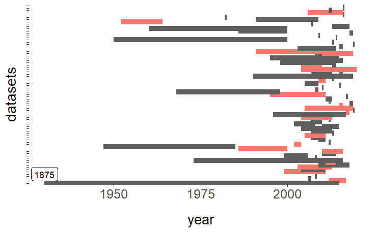

```r
p_temp_range <- ggplot(dataset_temp_range, aes(y=url, color = time_series)) +
  geom_segment(aes(x=temp_range_i, xend=temp_range_f, y=url, yend=url), linewidth=3)+
  xlab("year") +
  ylab ("datasets")+
  #theme_bw() +
  my.theme +
  theme(axis.text.y=element_blank())+
  scale_color_manual(values = c("gray37", "#F8766D"))+
  theme(legend.position = "none") +
  xlim(1930, round(max(dataset_temp_range$temp_range_f),0))+
  geom_label(
    label="1875",
    x=1930,
    y=5,
    #label.padding = unit(0.2, "lines"), # Rectangle size around label
    label.size = 0.1,
    color = "black"
   # fill="white"
  )

p_temp_range
```

```r
#ggsave("plots_repo/temporal_range.png", height = 7, width = 7)
```

### 3.2 Temporal duration counts

How many publications without temporal duration data?

```r
#nNa <- count_not.reported_temporal.duration(dataset)

print(paste(length(which(dataset$temporal_duration_position == "no")), "publications without temporal duration data"))
```

Publication counts by temporal duration (years):

```r
df_duration_counts <- count_durations(df = dataset, order_by = "counts")

df_duration_counts
```

Plot the results:

```r
plot_temp_duration <- plot_duration_counts(df = df_duration_counts,
                                           counts_Na = nNa)

plot_temp_duration

#ggsave("plots_repo/plot_temp_duration.png", height = 5, width = 9)
```

Average duration (for those with data):

```r
dataset_temp_duration <- subset(dataset,
                                  temporal_duration_y > 0 | temporal_duration_y == "no",
                                  select = c(temporal_duration_y,id_query))

  dataset_temp_duration$temporal_duration_y <- as.numeric(dataset_temp_duration$temporal_duration_y)


print(paste("mean of",
            round(mean(na.omit(dataset_temp_duration$temporal_duration_y)),digits = 1),
            "years"))
```

# 4. Spatial range

### 4.1 count spatial range publications

Publications that cant be accessed are not counted.

How many publications without spatial range data?

```r
n_not_reported <- count_not.reported_spatial_range(dataset)

print(paste(n_not_reported, "publications without spatial range data"))
```

```
[1] "27 publications without spatial range data"
```

Average spatial range:

```r
dataset1 <- dataset[dataset$dataset_relevance != "cant access",]

  dataset1$dataset_relevance <- as.factor(dataset1$dataset_relevance)

  spatial_range_km2_vec <- dataset1$spatial_range_km2[dataset1$spatial_range_km2 != ""]

  spatial_range_km2_vec <- spatial_range_km2_vec[!is.na(spatial_range_km2_vec)]

  spatial_range_km2_vec <- as.numeric(spatial_range_km2_vec)
print(paste("mean of",
            round(mean(na.omit(spatial_range_km2_vec)), digits = 0),
            "km2"))
```

```
[1] "mean of 1344104 km2"
```

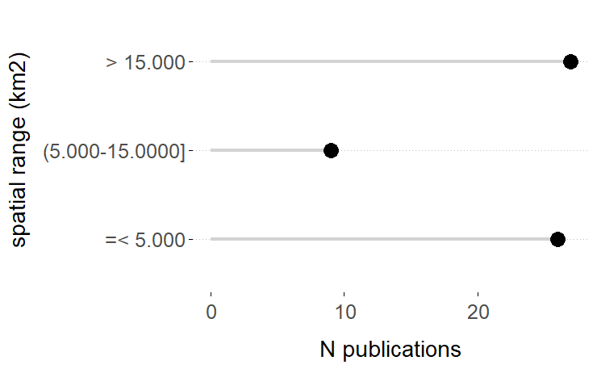

```r
plot_spatial_range_counts <- plot_spat.range_counts(dataset)+
  coord_flip()
plot_spatial_range_counts
```

```r
#ggsave("plots_repo/plot_spatial_range_counts.png", height = 6, width = 6)
```

#### Temporal duration, spatial range, relevance

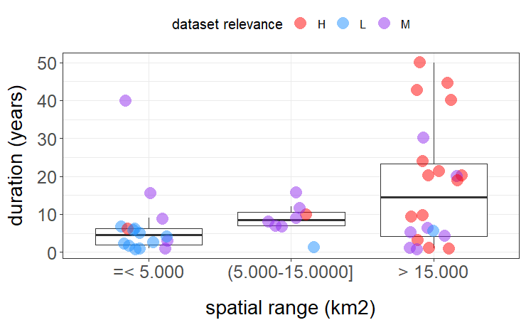

```r
plot_spatial_temporal_relevance <- plot_spat_temp_relevance(df = dataset)
plot_spatial_temporal_relevance
```

```r
#ggsave("plots_repo/plot_spatial_temporal_relevance.png", height = 6, width = 9)
```

# 5. EBV data types

```r
df_data_type_counts <- compute_df_data.type(df = dataset)

df_data_type_counts
```

| data_type_col | N_articles | percentage |
| --- | --- | --- |
| presence.only | 31 | 29.245283 |
| presence.absence | 9 | 8.490566 |
| abundance | 26 | 24.528302 |
| EBV_genetic | 27 | 25.471698 |
| genetic_analyses | 0 | 0.000000 |
| distribution | 3 | 2.830189 |
| other | 10 | 9.433962 |

```r
NA
```

Plot the results

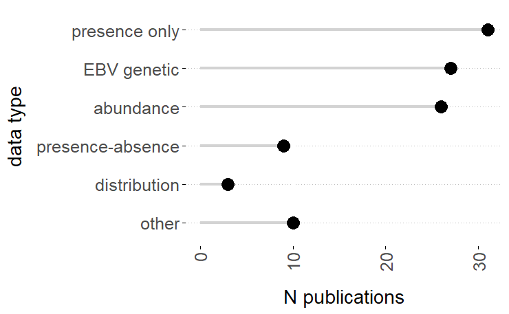

```r
plot_data_type <- plot_data.type_counts(df_data_type_counts)+
  coord_flip()

plot_data_type
```

```r
#ggsave("plots_repo/plot_data_type.png", height = 6, width = 9)
```

### Combine plots

[figure not shown]

```r
plot_combined_corpus <- ggarrange(
p_temp_range,
plot_spatial_temporal_relevance,
plot_data_type,
plot_spatial_range_counts,
nrow = 2,
ncol = 2,
  labels = c("a", "b", "c","d"),
font.label = list(size = 24),
heights = c(1,0.6))
plot_combined_corpus

ggsave("plots_repo/plot_combined_corpus.png", height = 10, width = 12)
```

# 6. Data format

Those datasets in the repository that are relevance category X don’t have format information.

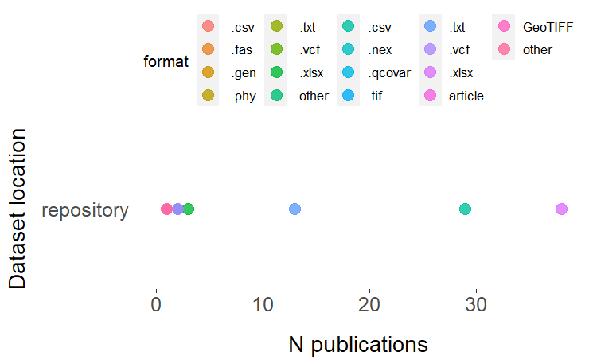

```r
plot_data_format_counts <- plot_data.type_format(dataset)

plot_data_format_counts
```

```r
#ggsave("plots_repo/plot_data_format_counts.png", height = 7, width = 9)
```

## 7. Journals

Count publications per journal

```r
dataset.j <- dataset[dataset$journal != "" & dataset$journal != "no",]

df_journals_counts <- as.data.frame(table(dataset.j$journal))

colnames(df_journals_counts) = c("Journal", "Publication_counts")

df_journals_counts <- df_journals_counts[order(-df_journals_counts$Publication_counts),]


df_journals_counts
```

```r
print(paste("A total of", length(df_journals_counts$Journal), "journals" ))
```

# 8. Location of information - features

### 8.1 % data type in abstract and title

Synonyms for the different EBV data type categories:

```r
df_dataset_types <- read.csv("../data/dataset_types.csv", sep = ";")
df_dataset_types
```

| type_dataset | keywords | keywords_type |
| --- | --- | --- |
| presence only | presence only | synonym |
| presence only | occurrence | synonym |
| presence only | specimen records | synonym |
| presence only | specimen | synonym |
| presence only | collection | synonym |
| presence-absence | presence-absence | synonym |
| presence-absence | sampling plot | methods |
| presence-absence | relative proportion | methods |
| presence-absence | inventory | methods |
| presence-absence | occupancy | methods |

[output cut: 16 more lines]

```r
df_dataset_types[nrow(df_dataset_types)+1,] <- c("presence-absence", "detection", "synonym")
df_dataset_types[nrow(df_dataset_types)+1,] <- c("presence-absence", "capture", "synonym")

df_dataset_types[nrow(df_dataset_types)+1,] <- c("EBV genetic analyses", "16S", "methods")
df_dataset_types[nrow(df_dataset_types)+1,] <- c("EBV genetic analyses", "18S", "methods")
df_dataset_types[nrow(df_dataset_types)+1,] <- c("EBV genetic analyses", "barcodes", "methods")
df_dataset_types[nrow(df_dataset_types)+1,] <- c("EBV genetic analyses", "haplotypes", "methods")
df_dataset_types[nrow(df_dataset_types)+1,] <- c("EBV genetic analyses", "eDNA", "methods")
df_dataset_types[nrow(df_dataset_types)+1,] <- c("EBV genetic analyses", "SNPs", "methods")

df_dataset_types
```

|  | type_dataset | keywords | keywords_type |
| --- | --- | --- | --- |
| 1 | presence only | presence only | synonym |
| 2 | presence only | occurrence | synonym |
| 3 | presence only | specimen records | synonym |
| 4 | presence only | specimen | synonym |
| 5 | presence only | collection | synonym |
| 6 | presence-absence | presence-absence | synonym |
| 7 | presence-absence | sampling plot | methods |
| 8 | presence-absence | relative proportion | methods |
| 9 | presence-absence | inventory | methods |
| 10 | presence-absence | occupancy | methods |

[output cut: 24 more lines]

```r
url <- c()
dataset_type <- c()
keyword_abs <- list()
keyword_title <- list()
#keyword_type <- c()
in_title <- c()
in_abstract <- c()


for (i in 1:nrow(dataset)) {



  dataset_type[i] <- dataset[i, "data_type"]
  url[i] <- dataset[i, "url"]




  # search on the abstract and note the list of keywords that match the dataset types

  keyword_abs[[i]] <- unique(get_keywords(input_string = dataset$full_text[i],
               dataset_types =  df_dataset_types))

  # if the list of keywords has 1 or more entry, then note that we found information in the abstract

  if(length(keyword_abs[i][!sapply(keyword_abs[i], is.null)]) == 0){

    in_abstract[i] <- "no"

  } else if (length(keyword_abs[i][!sapply(keyword_abs[i], is.null)]) > 0){

    in_abstract[i] <- "yes"

  }




  # search on the title and note the list of keywords that match the dataset types

  keyword_title[[i]] <- unique(get_keywords(input_string = dataset$title[i],
               dataset_types =  df_dataset_types))

  # if the list of keywords has 1 or more entry, then note that we found information in the abstract

  if(length(keyword_title[i][!sapply(keyword_title[i], is.null)]) == 0){

    in_title[i] <- "no"

  } else if (length(keyword_title[i][!sapply(keyword_title[i], is.null)]) > 0){

    in_title[i] <- "yes"

  }



}


dataset$data.type_in_abstract <- in_abstract
dataset$data_type_in_title <- in_title



print(paste(length(which(in_abstract == "yes")),
            "with dataset type or synonym explicit in the abstract, out of", length(in_abstract)))
```

```
[1] "84 with dataset type or synonym explicit in the abstract, out of 92"
```

```r
print(paste("so",
      round(length(which(in_abstract == "yes"))/length(in_abstract)*100, 1),
"%"))
```

```
[1] "so 91.3 %"
```

```r
print(paste(length(which(in_title == "yes")),
            "with dataset type or synonym explicit in the title, out of", length(in_title)))
```

```
[1] "24 with dataset type or synonym explicit in the title, out of 92"
```

```r
print(paste("so",
      round(length(which(in_title == "yes"))/length(in_title)*100, 1),
"%"))
```

```
[1] "so 26.1 %"
```

### 8.2 Temporal range and duration, spatial range, species, and data type location

```r
df_features.l <- dataset[,c("temporal_range_position", "temporal_duration_position", "spatial_range_position", "species_location", "data.type_in_abstract", "data_type_in_title")]

# add id

df_features.l$id <- c(1:nrow(df_features.l))



# separate by commas

df_features.l1 <- df_features.l %>%
  separate_rows(temporal_range_position, sep=",") %>%
  separate_rows(temporal_duration_position, sep=",") %>%
  separate_rows(spatial_range_position, sep=",") %>%
  separate_rows(species_location, sep=",")



# Homogenize levels

levels(as.factor(df_features.l1$species_location))
```

```
[1] " source publication text" "source link abstract"     "source publication text"
```

```r
df_features.l1$temporal_range_position[which(df_features.l1$temporal_range_position == " source link")] <- "repository text"
df_features.l1$temporal_range_position[which(df_features.l1$temporal_range_position == "source link")] <- "repository text"
df_features.l1$temporal_range_position[which(df_features.l1$temporal_range_position == "source link abstract")] <- "repository text"
df_features.l1$temporal_range_position[which(df_features.l1$temporal_range_position == " dataset")] <- "dataset"
df_features.l1$temporal_range_position[which(df_features.l1$temporal_range_position == " source publication text")] <- "article"
df_features.l1$temporal_range_position[which(df_features.l1$temporal_range_position == "source publication text")] <- "article"
df_features.l1$temporal_range_position[which(df_features.l1$temporal_range_position == "no")] <- "not given"



df_features.l1$temporal_duration_position[which(df_features.l1$temporal_duration_position == "source link")] <- "repository text"
df_features.l1$temporal_duration_position[which(df_features.l1$temporal_duration_position == "source link abstract")] <- "repository text"
df_features.l1$temporal_duration_position[which(df_features.l1$temporal_duration_position == "source publication text")] <- "article"
df_features.l1$temporal_duration_position[which(df_features.l1$temporal_duration_position == "no")] <- "not given"



df_features.l1$spatial_range_position[which(df_features.l1$spatial_range_position == "source link")] <- "repository text"
df_features.l1$spatial_range_position[which(df_features.l1$spatial_range_position == "source link abstract")] <- "repository text"
df_features.l1$spatial_range_position[which(df_features.l1$spatial_range_position == "source publication text")] <- "article"
df_features.l1$spatial_range_position[which(df_features.l1$spatial_range_position == "no")] <- "not given"



df_features.l1$species_location[which(df_features.l1$species_location == "source link abstract")] <- "repository text"
df_features.l1$species_location[which(df_features.l1$species_location == "source publication text")] <- "article"
df_features.l1$species_location[which(df_features.l1$species_location == " source publication text")] <- "article"


df_features.l1
```

| temporal_range_position | temporal_duration_position | spatial_range_position | species_location | data.type_in_abstract | data_type_in_title | id |
| --- | --- | --- | --- | --- | --- | --- |
| repository text | not given | not given | NA | yes | no | 1 |
| dataset | not given | not given | NA | yes | no | 1 |
| repository text | not given | not given | NA | no | no | 2 |
| not given | not given | not given | repository text | yes | no | 3 |
| article | article | not given | NA | yes | yes | 4 |
| dataset | article | not given | NA | yes | yes | 4 |
| repository text | not given | not given | NA | yes | no | 5 |
| repository text | repository text | article | NA | yes | no | 6 |
| article | repository text | article | NA | yes | no | 6 |
| dataset | repository text | article | NA | yes | no | 6 |

[output cut: 130 more lines]

```r
NA
```

How many with all the features readily accessible (in repository text):

```r
n_all <- nrow(na.omit(df_features.l1[
                   df_features.l1$data.type_in_abstract == "yes" &
                   df_features.l1$temporal_range_position == 'repository text' &
                   df_features.l1$spatial_range_position == 'repository text',]))

print(paste(n_all, "with all the features readily accessible (in the repository text) - a", round(n_all/nrow(dataset)*100, 3),"%"))
```

```
[1] "0 with all the features readily accessible (in the repository text) - a 0 %"
```

How many with at least one feature accessible

```r
df_features.l2 <- df_features.l1[!is.na(df_features.l1$data.type_in_abstract),]

df_features.l2 <- df_features.l1[
  df_features.l1$data_type_in_title == "yes" |
                   df_features.l1$data.type_in_abstract == "yes" |
                   df_features.l1$temporal_range_position == 'repository text' |
                   df_features.l1$spatial_range_position == 'repository text', ]

df_features.l2 <- df_features.l2[!is.na(df_features.l2$data.type_in_abstract),]
n_any <- length(unique(df_features.l2$id))

print(paste(n_any, "with at least one feature readily accessible (in the repository text) - a", round(n_any/nrow(dataset)*100, 3),"%"))
```

```
[1] "85 with at least one feature readily accessible (in the repository text) - a 92.391 %"
```

How many per feature type

```r
df_locations_plot <- count_position_features(dataset)
```

```
[1] "91 analyzed for temp range position"
[1] "91 analyzed for temp range position"
[1] "86 analyzed for temp range position"
```

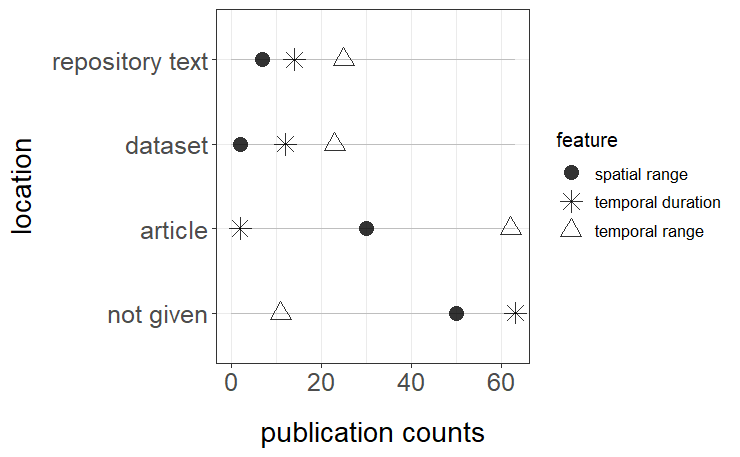

```r
plot_location_features <- ggplot(df_locations_plot, aes(x=location, y = Freq, group = feature)) +
   geom_segment( aes(x=location ,xend=location, y=0, yend=max(Freq)), color="grey") +
    geom_point(aes(shape = feature),size=4, alpha = 0.8) +
    coord_flip() +
  theme_bw() +
  my.theme+
  #scale_color_manual(values = c("deepskyblue2","firebrick1","indianred4"))+
  scale_shape_manual(values = c(16,8,2))+
  ylab("publication counts")

plot_location_features
```

```r
#ggsave("plots_repo/location_features.png", height = 5, width = 9)
```

#9. Spatial information format

```r
# Eliminate Nas

geospatial_info_article_text <- dataset$geospatial_info_article_text[-which(is.na(dataset$geospatial_info_article_text))]

geospatial_info_dataset <- dataset$geospatial_info_dataset[-which(is.na(dataset$geospatial_info_dataset))]

geospatial_info_repo_page_text <- dataset$geospatial_info_repo_page_text[-which(is.na(dataset$geospatial_info_repo_page_text))]


# Separate by commas

geospatial_info_article_text  <- unlist(strsplit(geospatial_info_article_text,","))

geospatial_info_dataset  <- unlist(strsplit(geospatial_info_dataset,","))

geospatial_info_repo_page_text  <- unlist(strsplit(geospatial_info_repo_page_text,","))



# Homogenize names

## column geospatial_info_article_text

geospatial_info_article_text[which(geospatial_info_article_text == " administrative unit")] <- "administrative unit"
geospatial_info_article_text[which(geospatial_info_article_text == " range coordites")] <- "range coordinates"
geospatial_info_article_text[which(geospatial_info_article_text == " site coordites")] <- "site coordinates"
geospatial_info_article_text[which(geospatial_info_article_text == "site coordites")] <- "site coordinates"
geospatial_info_article_text[which(geospatial_info_article_text == " geological feature me")] <- "geographic feature"
geospatial_info_article_text[which(geospatial_info_article_text == "geological feature me")] <- "geographic feature"
geospatial_info_article_text[which(geospatial_info_article_text == " Map")] <- "Map"
geospatial_info_article_text[which(geospatial_info_article_text == "Map")] <- "map"
geospatial_info_article_text[which(geospatial_info_article_text == "administration unit")] <- "administrative unit"
geospatial_info_article_text[which(geospatial_info_article_text == "Administrative unit")] <- "administrative unit"
geospatial_info_article_text[which(geospatial_info_article_text == "no")] <- "not given"


## column geospatial_info_dataset

geospatial_info_dataset[which(geospatial_info_dataset == " site coordites")] <- "site coordinates"
geospatial_info_dataset[which(geospatial_info_dataset == "  site coordites")] <- "site coordinates"
geospatial_info_dataset[which(geospatial_info_dataset == "site coordites")] <- "site coordinates"
geospatial_info_dataset[which(geospatial_info_dataset == "sample coordites")] <- "sample coordinates"
geospatial_info_dataset[which(geospatial_info_dataset == " sample coordites")] <- "sample coordinates"
geospatial_info_dataset[which(geospatial_info_dataset == " administrative unit")] <- "administrative unit"
geospatial_info_dataset[which(geospatial_info_dataset == " site IDs")] <- "site IDs"
geospatial_info_dataset[which(geospatial_info_dataset == " IDs")] <- "site IDs"
geospatial_info_dataset[which(geospatial_info_dataset == " geographic feature")] <- "geographic feature"
geospatial_info_dataset[which(geospatial_info_dataset == "no")] <- "not given"



## column geospatial_info_repo_page_text

geospatial_info_repo_page_text[which(geospatial_info_repo_page_text == "geological feature me")] <- "geographic feature"
geospatial_info_repo_page_text[which(geospatial_info_repo_page_text == "Administrative unit")] <- "administrative unit"
geospatial_info_repo_page_text[which(geospatial_info_repo_page_text == "no")] <- "not given"
```

```r
# Make dataframe with counts

location <- rep("article text", times = length(geospatial_info_article_text))

df_article <- data.frame(geospatial_info_article_text, location)

location <- rep("repository page", times = length(geospatial_info_repo_page_text))

df_repo<- data.frame(geospatial_info_repo_page_text, location)

location <- rep("dataset", times = length(geospatial_info_dataset))

df_dataset <- data.frame(geospatial_info_dataset, location)

colnames(df_article) <- c("information", "location")
colnames(df_repo) <- c("information", "location")
colnames(df_dataset) <- c("information", "location")

df_locations <- rbind(df_article,df_repo,df_dataset)

df_locations$information[which(df_locations$information == "site IDs") ] <- "sites IDs"
df_locations$information[which(df_locations$information == "site coordites") ] <- "site coordinates"
df_locations$information[which(df_locations$information == "Map") ] <- "map"
df_locations$information[which(df_locations$information == "geologial feature") ] <- "geographic feature"
df_locations$information[which(df_locations$information == "geographical feature") ] <- "geographic feature"
```

Plot results

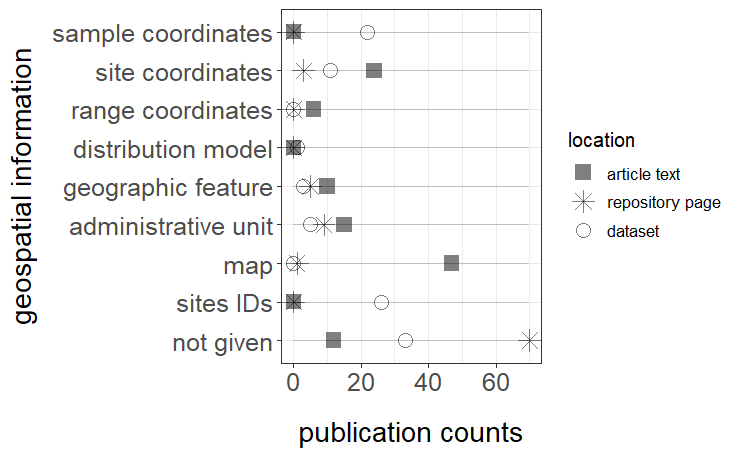

# 10. Semantic Scholar

#### Read data

```r
## Only Semantic Scholar

dataset_sc <- read.csv("../data/merged_datasets.csv", header = TRUE,sep=",")

dataset_sc <- dataset_sc[which(dataset_sc$title != ""),]
dataset_sc <- dataset_sc %>% dplyr::filter(valid_yn == "yes")

dataset_sc <- dataset_sc[which(dataset_sc$source == "semantic_scholar"),]
```

```r
table(dataset_sc$valid_yn)
```

```r
table(dataset_sc$reason_non_valid[which(dataset_sc$valid_yn=="no")])
```

### 10.1. Number of datasets and relevance categories

Only Semantic Schoar

```r
df_N_relevance <- count_by_relevance(dataset_sc)

df_N_relevance
```

|  | dataset relevance | N |
| --- | --- | --- |
| 5 | No dataset | 59 |
| 3 | L | 28 |
| 4 | M | 21 |
| 1 | cant access | 20 |
| 6 | X | 9 |
| 2 | H | 3 |

### 10.2 Relevance counts by source

(only when comparing semantic scholar with repos)

|  | relevance | dryad | semantic_scholar | zenodo | repositories |
| --- | --- | --- | --- | --- | --- |
| 1 | H | 10 | 3 | 11 | 21 |
| 3 | M | 13 | 21 | 21 | 34 |
| 2 | L | 16 | 28 | 24 | 40 |
| 6 | X | 3 | 9 | 13 | 16 |
| 5 | No dataset | 0 | 59 | 0 | 0 |
| 4 | No access | 0 | 20 | 1 | 1 |

Plot the results:

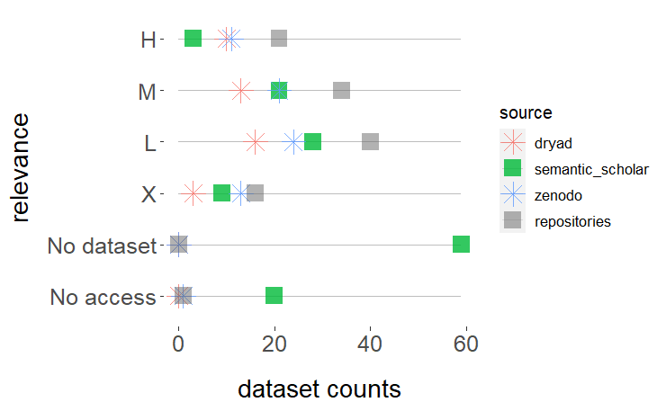

### 10.3 Data Format

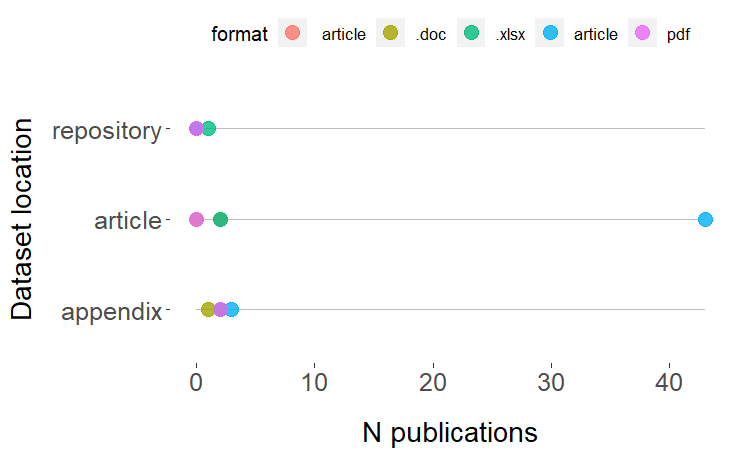

```r
dataset1 <- dataset_sc[dataset_sc$dataset_location != "no",]
dataset1 <- dataset_sc[dataset_sc$dataset_format != "",]

plot_data.type_format(dataset1)
```

```r
#ggsave("plots_semantic_scholar/formats_semschol.png", height = 5, width = 8)
```

### 10.4 Source of information across time

```r
dataset_st$dataset_relevance
```

```
  [1] "M" "M" "L" "M" "H" "H" "L" "L" "L" "L" "L" "L" "M" "L" "L" "L"
 [17] "H" "M" "M" "M" "H" "M" "M" "H" "M" "H" "H" "H" "L" "M" "L" "L"
 [33] "H" "L" "L" "M" "M" "L" "H" "H" "M" "H" "M" "H" "L" "L" "L" "M"
 [49] "L" "L" "L" "L" "M" "H" "H" "M" "M" "M" "M" "L" "M" "L" "L" "H"
 [65] "L" "L" "L" "L" "M" "L" "L" "M" "L" "L" "M" "M" "H" "M" "L" "L"
 [81] "M" "H" "H" "M" "L" "M" "M" "H" "L" "L" "M" "M" "H" "H" "H" "M"
 [97] "M" "L" "L" "H" "L" "L" "M" "L" "M" "L" "H" "L" "L" "M" "L" "M"
[113] "M" "L" "L" "M" "M" "L" "L" "M" "L" "M" "M" "L" "L" "L" "L" "H"
[129] "L" "M" "M" "L" "M" "M" "L" "L" "M" "L" "L" "M" "L" "L" "M" "M"
[145] "L" "M" "L" "L" "H" "M"
```

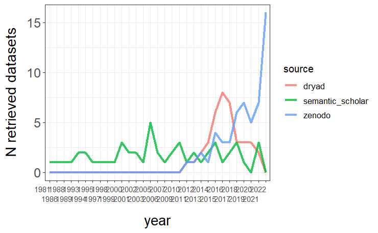

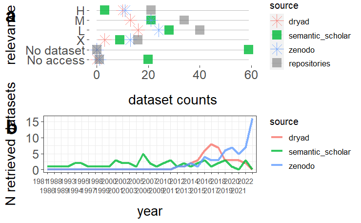

# 11. Taxa (repos)

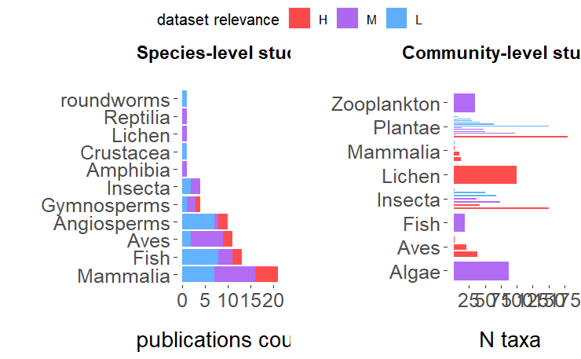